# Visualization

## Coloring and filling

Any changes to the appearance of the curve itself are made within the argument that specifies the geometric object to be plotted, here `geom_line()`. `R` knows many colors by name; for a great overview see this [resource](http://www.stat.columbia.edu/~tzheng/files/Rcolor.pdf).

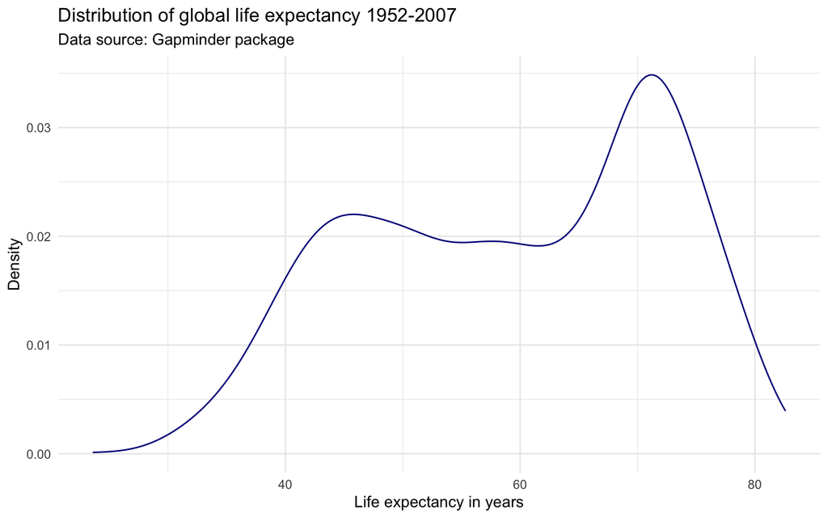

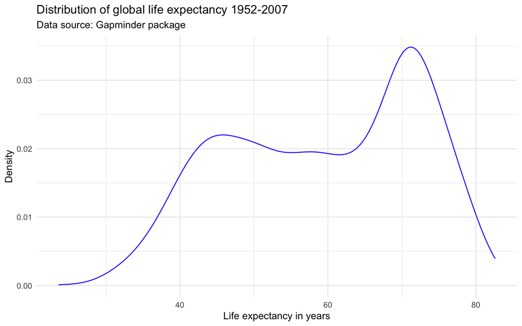

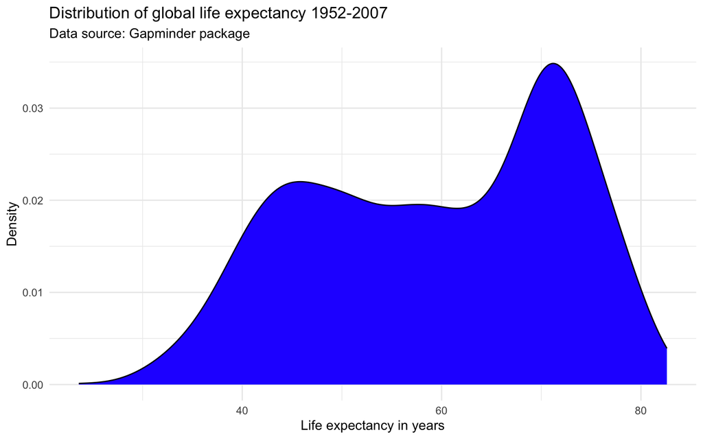

```r
# color with name
ggplot(df, aes(x = lifeExp)) +
  geom_density(color = "darkblue") +
  labs(title = "Distribution of global life expectancy 1952-2007",
       subtitle = "Data source: Gapminder package",
       x = "Life expectancy in years",
       y = "Density") +
  theme_minimal()

# color with hex
ggplot(df, aes(x = lifeExp)) +
  geom_density(color = "#2727ff") +
  labs(title = "Distribution of global life expectancy 1952-2007",
       subtitle = "Data source: Gapminder package",
       x = "Life expectancy in years",
       y = "Density") +
  theme_minimal()

# color + fill
ggplot(df, aes(x = lifeExp)) +
  geom_density(color = "#000000",
               fill = "#2727ff") +
  labs(title = "Distribution of global life expectancy 1952-2007",
       subtitle = "Data source: Gapminder package",
       x = "Life expectancy in years",
       y = "Density") +
  theme_minimal()
```

We can also use hexadecimal or RGB (red, green, blue) strings to specify colors. There are plenty of online tools to pick colors and extract hexadecimal or RBG strings. One of our favorites is [this one](http://www.colorhexa.com). This online tool allows you to specify a color name, hexadecimal, or RGB string, and returns information on color schemes, complementary colors, as well as alternative shades, tints, and tones. It also offers a color blindness simulator.

Suppose, I like the general tone of the darkblue color above but am worried that it is a bit too dark for my plot. I enter the color “darkblue” into the search field at http://www.colorhexa.com and look for a brighter alternative. Suppose I really like the color displayed in the second tile from the left on the tints scale. I can extract this color’s hexadecimal value of `#2727ff` by hovering over the tile of that color.

Another good source for color schemes is [colorbrewer2](https://colorbrewer2.org), which also has an R binding, `RColorBrewer`.

## Line types and width

We can adjust the *type* of the line via the `linetype` parameter within `geom_line()`. For an overview of line types see [here](http://sape.inf.usi.ch/quick-reference/ggplot2/linetype).

We can adjust the *width* of the line via the `size` parameter within `geom_line()`. Note that the `size` parameter is universal in the way that it controls line width in line plots and point size in scatter plots.

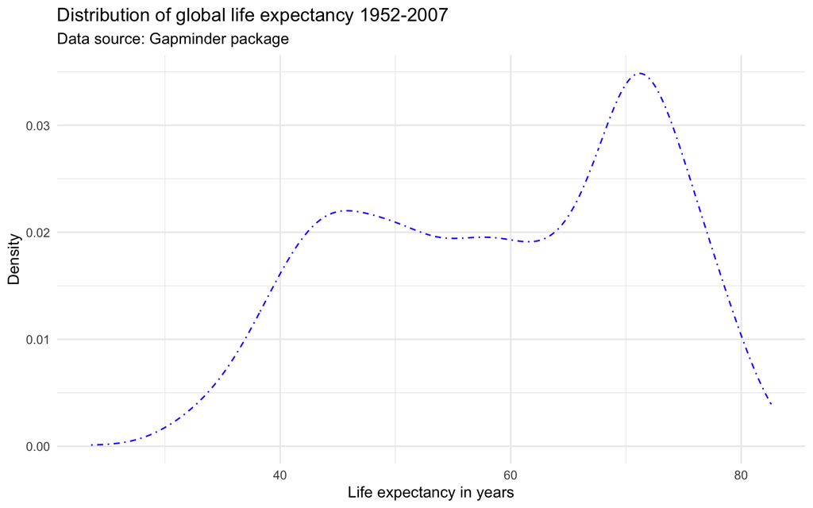

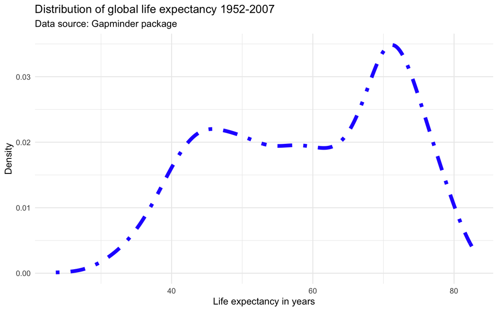

```r
ggplot(df, aes(x = lifeExp)) +
  geom_line(stat = "density",
            color = "#2727ff",
            linetype = "dotdash") +
  labs(title = "Distribution of global life expectancy 1952-2007",
       subtitle = "Data source: Gapminder package",
       x = "Life expectancy in years",
       y = "Density") +
  theme_minimal()

ggplot(df, aes(x = lifeExp)) +
  geom_line(stat = "density",
            color = "#2727ff",
            linetype = "dotdash",
            size = 2) +
  labs(title = "Distribution of global life expectancy 1952-2007",
       subtitle = "Data source: Gapminder package",
       x = "Life expectancy in years",
       y = "Density") +
  theme_minimal()
```

## Opacity

We can adjust the *opacity* via the `alpha` parameter within any geometric object. The `alpha` parameter ranges between zero and one. Adjusting the opacity of the geometric objects is especially important when plotting multiple lines, points (or other objects) in the same graph to reduce overplotting.

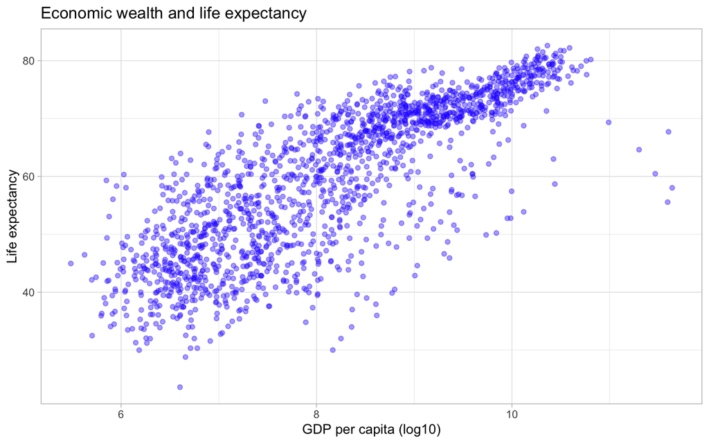

```r
ggplot(df, aes(x = log(gdpPercap), y = lifeExp)) +
  geom_point(alpha = 0.4, color = "#2727ff") +
  labs(title = "Economic wealth and life expectancy",
       x = "GDP per capita (log10)",
       y = "Life expectancy") +
  theme_light()
```

## Symbols/shapes

We can adjust the default symbol used by `ggplot2` to display the points. The parameter is called [`shape`](http://www.sthda.com/english/wiki/ggplot2-point-shapes).

We can also have groups of data displayed using different point shapes. Below, we group by continent. We subset the data to just the year 2007 to de-clutter the plot.

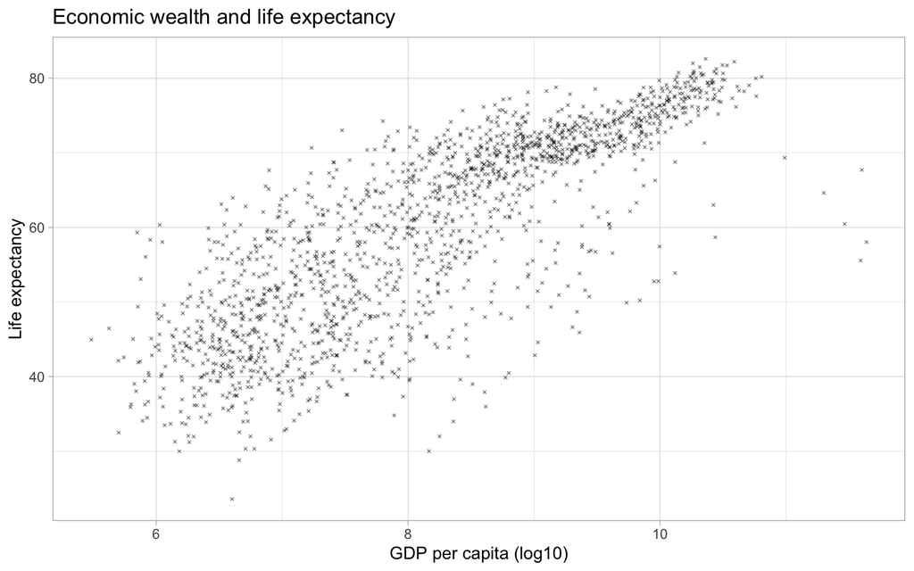

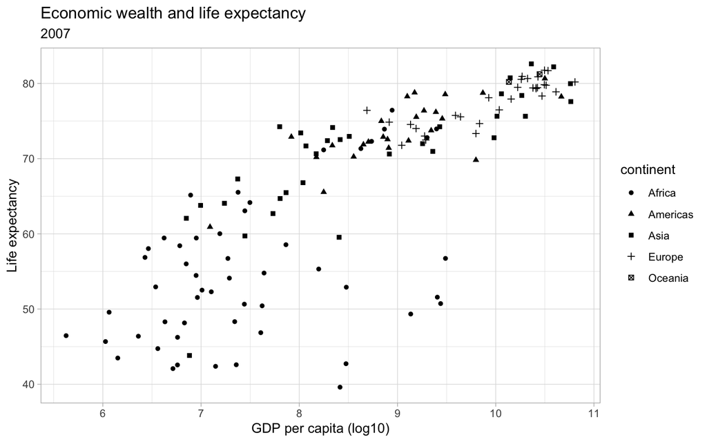

```r
ggplot(df, aes(x = log(gdpPercap), y = lifeExp)) +
  geom_point(alpha = 0.4,
             size = 0.5,
             shape = 4) +
  labs(title = "Economic wealth and life expectancy",
       x = "GDP per capita (log10)",
       y = "Life expectancy") +
  theme_light()

ggplot(subset(df, year == 2007),
       aes(x = log(gdpPercap),
           y = lifeExp,
           shape = continent)) +
  geom_point() +
  labs(title = "Economic wealth and life expectancy",
       subtitle = "2007",
       x = "GDP per capita (log10)",
       y = "Life expectancy") +
  theme_light()
```

## Themes

# Comparing groups 🍎 🍐

## Using different colors

Sometimes, we want to compare distributions across different groups in our data set. Suppose, we wanted to assess the distribution of the life expectancy on different continents. We can use the `table()` function to get an overview over the groups in our data.

```r
table(df$continent)
```

```
##
##   Africa Americas     Asia   Europe  Oceania
##      624      300      396      360       24
```

We pass a separate color to the distribution of the `lifeExp` for each continent by specifying the `color` parameter within the aesthetics. Remember, to remove the `color` parameter from the `geom_line()` function. The ability to pass a second variable to the graph with just one aesthetic (here: color) is where the true power of `ggplot2` for data visualization lies.

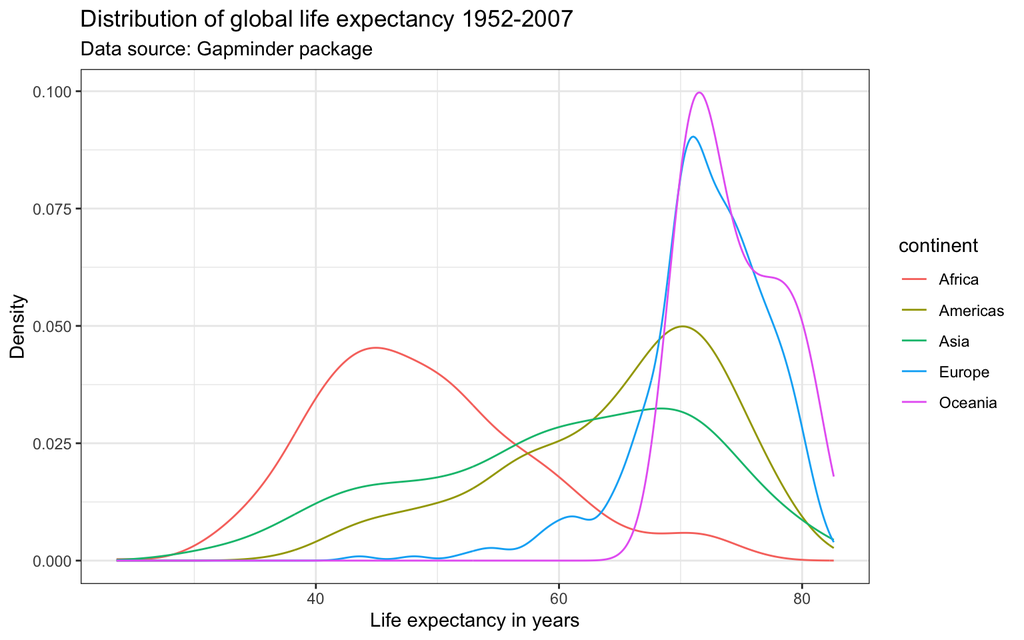

```r
ggplot(df, aes(x = lifeExp, color = continent)) +
  geom_line(stat = "density") +
  labs(title = "Distribution of global life expectancy 1952-2007",
       subtitle = "Data source: Gapminder package",
       x = "Life expectancy in years",
       y = "Density") +
  theme_bw()
```

We can adjust the colors used in the plot in a variety of ways. Below, we first use the `scale_color_manual()` function. This will change the colors in both the plot and the legend, based on our manual specification. Within the `scale_color_manual()` argument, we can also specify a name and labels for the legend.

There are a ton of resources and packages with pre-defined color schemes. The most popular is [colorbrewer2](https://colorbrewer2.org/#type=sequential&scheme=BuGn&n=3). You can either pick the desired colors manually, or use the `scale_color_brewer()` function in `ggplot2()`.

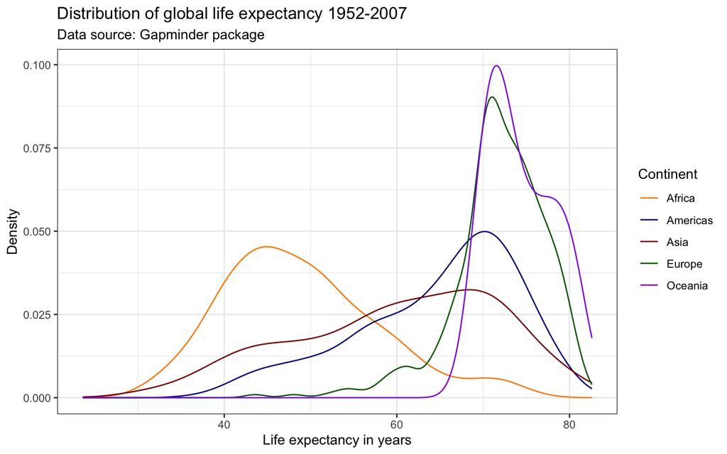

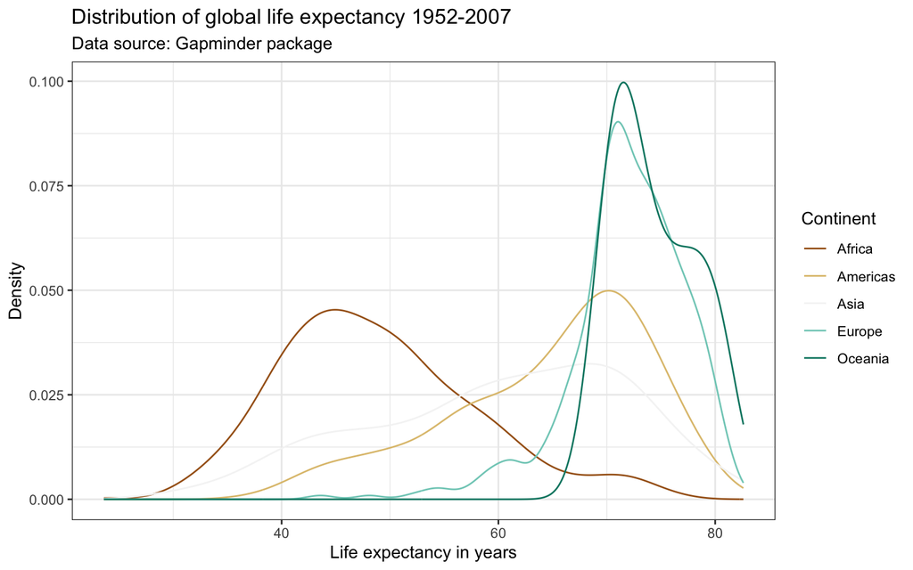

```r
# manual set-up for colors
ggplot(df, aes(x = lifeExp, color = continent)) +
  geom_line(stat = "density") +
  labs(title = "Distribution of global life expectancy 1952-2007",
       subtitle = "Data source: Gapminder package",
       x = "Life expectancy in years",
       y = "Density") +
  theme_bw() +
  scale_color_manual(values = c("Africa" = "darkorange",
                                "Americas" = "darkblue",
                                "Europe" = "darkgreen",
                                "Asia" = "darkred",
                                "Oceania" = "purple2"),
                     name = "Continent")

# using a pre-established palette
ggplot(df, aes(x = lifeExp, color = continent)) +
  geom_line(stat = "density") +
  labs(title = "Distribution of global life expectancy 1952-2007",
       subtitle = "Data source: Gapminder package",
       x = "Life expectancy in years",
       y = "Density") +
  theme_bw() +
  scale_color_brewer(palette = "BrBG",
                     name = "Continent")
```

Check out the list of color palettes compiled by [Emil Hvitfeldt](https://github.com/EmilHvitfeldt/r-color-palettes/blob/master/type-sorted-palettes.md#sequential-color-palettes). There is even a Wes Anderson movies inspired color scheme available using the package [wesanderson](https://github.com/karthik/wesanderson#the-isle-of-dogs-2018)! Another popular option are the color schemes from the [viridis](https://cran.r-project.org/web/packages/viridis/vignettes/intro-to-viridis.html) package due to their desirable properties with respect to colorblindness and printability.

## Using different linetypes

Sometimes you will be printing on a gray scale. This means that color will not be enough to differentiate five lines. We can use different line types instead by specifying the `linetype` parameter within the `aes()` argument. This also makes the graph more color blind friendly. Notice below that in order to combine the legends for the `linetype` and `color` aesthetics, we need to pass the same name within the `scale` function.

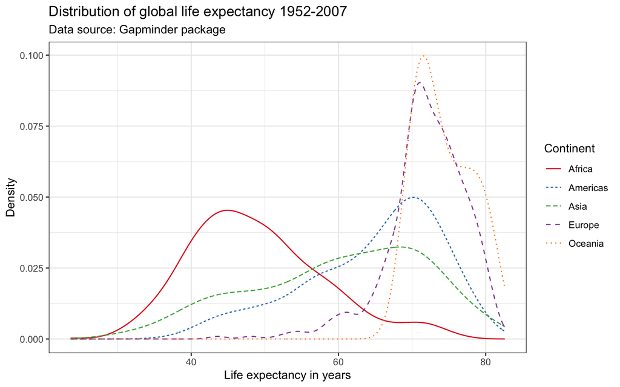

```r
ggplot(df, aes(x = lifeExp, color = continent, linetype = continent)) +
  geom_line(stat = "density") +
  labs(title = "Distribution of global life expectancy 1952-2007",
       subtitle = "Data source: Gapminder package",
       x = "Life expectancy in years",
       y = "Density") +
  theme_bw() +
  scale_color_brewer(palette = "Set1",
                     name = "Continent") +
  scale_linetype_discrete(name = "Continent")
```

## Faceting

Another option to graph different groups is to use faceting. This means to plot each value of the variable upon which we facet in a different panel within the same plot. Here, we will use the `facet_wrap()` function.

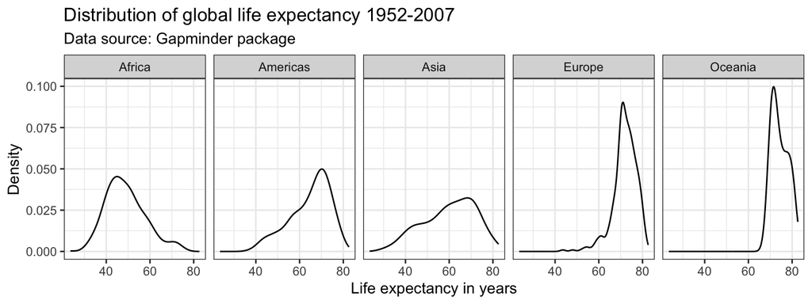

```r
ggplot(df, aes(x = lifeExp)) +
  geom_line(stat = "density") +
  labs(title = "Distribution of global life expectancy 1952-2007",
       subtitle = "Data source: Gapminder package",
       x = "Life expectancy in years",
       y = "Density") +
  theme_bw() +
  facet_wrap(~ continent, nrow = 1)
```

We can use the `facet_grid()` to create facets across more than one variable. Suppose, we were interested in the evolution of the distribution of the life expectancy over time for each continent.

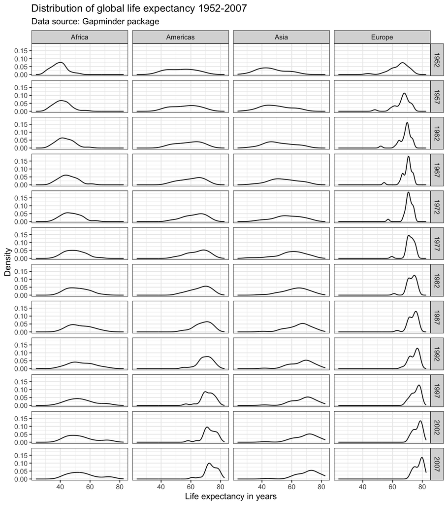

```r
ggplot(subset(df, continent != "Oceania"),
       aes(x = lifeExp)) +
  geom_line(stat = "density") +
  labs(title = "Distribution of global life expectancy 1952-2007",
       subtitle = "Data source: Gapminder package",
       x = "Life expectancy in years",
       y = "Density") +
  theme_bw() +
  facet_grid(year ~ continent)
```

## Exercise 4 - Groups and Relationships

Create a plot to compare the GDP per capita development of the BRICS countries (Brazil, Russia, India, China, South Africa). Unfortunately, Russia (or previously the Soviet Union) is not part of the `gapminder` data, so we cannot display it in the plot.

```r
# YOUR CODE HERE
```

# Saving plots 💾

We can output your plots to many different format using the `ggsave()` function, including but not limited to `.pdf`, `.jpeg`, `.bmp`, `.tiff`, or `.eps`. Here, we output the graph as a Portable Network Graphics (.png) file. We can specify the size of the output graph as well as the resolution in dots per inch (dpi). If no graph is specified, `ggsave()` will save the last graph that was executed. If we do not specify the complete file path, the plot will be saved to your working directory.

```r
# ggsave("panel_lifeexp_continent.png", width = 6, height = 3, dpi = 400)
```

Alternatively, we could save the plot as an `R` object and pass the object name to `ggsave()`. Also, remember our project folder structure we discussed in one of the first weeks. You might have an image or output folder in your project directory.

```r
p1 <- ggplot(df,
       aes(x = lifeExp)) +
  geom_density()

#ggsave("lifeexp_dens.png", width = 3, height = 2, dpi = 300, p1)

# or with a more precise folder structure:
#ggsave("output/images/lifeexp_dens.png", width = 3, height = 2, dpi = 300, p1)
```

Manually, you could also visit the `Plots` pane in the RStudio interface and export the graph as image or pdf.

Oftentimes, we want our plots not only to be displayed side by side in an html output, but we actually want to save it as a two (or more) image file. The function `grid.arrange()` from the `gridExtra` package - see this [vignette](https://cran.r-project.org/web/packages/egg/vignettes/Ecosystem.html) for more information- can be very helpful here.

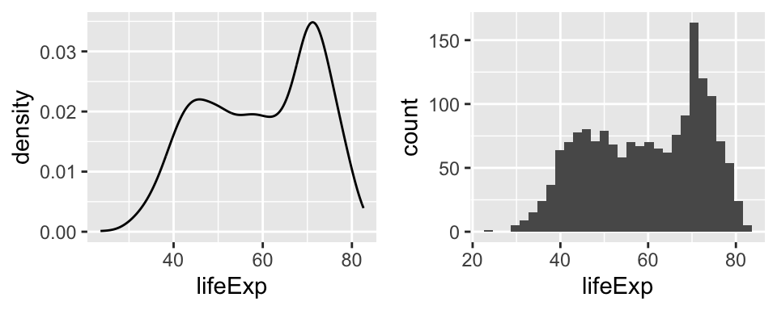

```r
p1 <- ggplot(df, aes(x = lifeExp)) +
  geom_density()

p2 <- ggplot(df,aes(x = lifeExp)) +
  geom_histogram()

p3 <- grid.arrange(p1, p2, nrow = 1)
```

```r
p3
```

```r
#ggsave("lifeexp_double.png", width = 6, height = 2, dpi = 300, p3)
```

# Next steps 🎒

Now that you have been introduced to some of the basics of `ggplot2`, **the best way to move forward is to experiment**. As we have discussed before, the **R** community is very open. Perhaps, you can gather some inspiration from the [Tidy Tuesday](https://github.com/rfordatascience/tidytuesday) social data project in R where users explore a new dataset each week and share their visualizations and code on Twitter under #TidyTuesday. You can explore some of the previous visualizations [here](https://shiny.rstudio.com/gallery/tidy-tuesday.html) and try to replicate their code.

[Here](https://github.com/erikgahner/awesome-ggplot2) and [here](https://exts.ggplot2.tidyverse.org/gallery/) are curated lists of awesome `ggplot2` resources. Other cool plot forms to check out are, for example, parallel plots, spaghetti plots, interactive plots, maps, three dimensional plots, network graphs, etc. Of course, there will also be some really cool visualization content in the workshops!!

In case you’re already thinking about Christmas gifts, want to have some more color on your walls or - just in case you are bored by this course, check out some *generative art* or play around with some open projects, for example, by [Katharina Brunner](https://katharinabrunner.de/generativeart/), [Ijeamaka](https://twitter.com/ijeamaka_a) or [Sharla Gelfand](https://twitter.com/sharlagelfand) - all **conducted in R**!

# **Acknowledgements**

This tutorial is based largely on chapters 7 to 10 from the [Quantitative Politics with R book](https://github.com/erikgahner/qpolr/blob/master/README.md) and [Wilkinson, L., 2012. The grammar of graphics](https://link.springer.com/book/10.1007/0-387-28695-0). In Handbook of Computational Statistics (pp. 375-414). Springer, Berlin, Heidelberg.

This script was drafted by [Tom Arendt](https://github.com/tom-arend) and [Lisa Oswald](https://lfoswald.github.io/), with contributions by [Steve Kerr](https://smkerr.github.io/), [Hiba Ahmad](https://github.com/hiba-ahmad), [Carmen Garro](https://github.com/cgarroca), [Sebastian Ramirez-Ruiz](https://seramirezruiz.github.io/), [Killian Conyngham](https://github.com/Killian-Conyngham) and [Carol Sobral](https://github.com/cbsobral).

[^1]: For more information about the logic behind developing the viridis palette, see [this blog post](https://www.r-bloggers.com/ggplot2-welcome-viridis/).